# Chapter 2: Homework

711378912 蔡宜諠

3/19/2025

# 作業題目：性別與酒精攝取之關聯

## ✅實驗：

有一個實驗，在某機構的員工中隨機訪問了100名男性與80名女性，其中有90名男性與20名女性在上個週末有超過安全標準的酒精攝取。請問在該機構中，性別是否影響超過安全標準的酒精攝取。 以下簡稱：超過安全標準的酒精為”超標”，未超過安全標準的酒精為”未超標”。

|  | 超標 Yes | 未超標 No | 總計 Total |
| --- | --- | --- | --- |
| 男性 Male | 90 | 10 | 100 |
| 女性 Female | 20 | 60 | 80 |
| 總計 Total | 110 | 70 | 180 |

```r
A <- matrix(c(90,20,10,60), 2, 2); B <- A
rownames(B) <- c("Male", "Female")
colnames(B) <- c("Yes", "No")
B
```

```
##        Yes No
## Male    90 10
## Female  20 60
```

## ✅觀察：

- 超標的機率為何？

  Pr（超標）= 110 / 180 = 0.611
- 男性中，超標的機率為何：
  - $\pi_1 =$ Pr（男性且超標｜男性）
  - $\widehat{\pi_1}= 90 / 100 \approx 0.9$
- 女性中，超標的機率為何：
  - $\pi_2 =$ Pr（女性且超標｜女性）
  - $\widehat{\pi_2} = 20 / 80 \approx 0.25$

## ✅問題：「性別」是否影響「超過安全標準的酒精攝取」？？？

## 📊 回答：

以下將以四個角度：**差異檢定 Difference of Proportions** 來比較不同性別的超標機率、**相對風險 RR** 來衡量風險差距、**勝算比 OR** 來評估相對機率、**獨立性檢定 Independence Test** 來檢測是否有統計上的顯著關聯，來回答這個問題：

### 一、差異檢定 Difference of Proportions $H_0: \pi_1 - \pi_2 = 0$ vs $H_a: \pi_1 - \pi_2 \neq 0$

- 公式
  - $d = \hat\pi_1 - \hat\pi_2$
  - $$Var(d) = \frac{\hat\pi_1 (1-\hat\pi_1)}{n_1}
    + \frac{\hat\pi_2 (1-\hat\pi_2)}{n_2}$$
  - $(1-\alpha)\times 100$% CI of $\pi_1-\pi_2$ is
    $$\left(d - z_{\alpha/2}\times \sqrt{Var(d)}, \quad
    d + z_{\alpha/2}\times \sqrt{Var(d)}\right)$$
- 計算過程

```r
pi_1_hat <- B[1,1]/sum(B[1,]); pi_1_hat
```

```
## [1] 0.9
```

```r
pi_2_hat <- B[2,1]/sum(B[2,]); pi_2_hat
```

```
## [1] 0.25
```

```r
diff <- pi_1_hat - pi_2_hat; diff
```

```
## [1] 0.65
```

```r
var_diff <- pi_1_hat*(1-pi_1_hat)/sum(B[1,]) +
  pi_2_hat*(1-pi_2_hat)/sum(B[2,])
ub <- diff + qnorm(.975)*sqrt(var_diff)
lb <- diff + qnorm(.025)*sqrt(var_diff)
cat("The estimate of pi_1 - pi_2 is", diff, "\n")
```

```
## The estimate of pi_1 - pi_2 is 0.65
```

```r
cat("The corresponding 95 CI for diff is [", lb, " , ", ub, "]\n")
```

```
## The corresponding 95 CI for diff is [ 0.5383724  ,  0.7616276 ]
```

- **結論：**
  - 男性的超標酒精攝取機率為 0.9，而女性的超標機率為 0.25。
  - 由於上述 95% 信賴區間 **(0.5383724, 0.7616276)** 不包含 0，因此拒絕虛無假設。
  - 由於 **$\hat{\pi}_1 - \hat{\pi}_2 > 0$**，我們的結論為，男性的超標機率顯著高於女性，這顯示性別對超標酒精攝取行為有統計上的顯著影響。

### 二、相對風險 Relative Risk $H_0: \pi_1/\pi_2 = 1$

- 公式
  - $RR = \pi_1/\pi_2$ and $\hat{RR} = \hat\pi_1/\hat\pi_2$
  - $$\log(\hat{RR}) \sim N\left( \log(RR), \hat{Var}(\log(\hat{RR}))\right)
    \quad \mbox{where} \quad \hat{Var}(\log(\hat{RR}))
    =\frac{1-\hat\pi_1}{n_{1+}\hat\pi_1} +
    \frac{1-\hat\pi_2}{n_{2+}\hat\pi_2}$$
  - $(1-\alpha)\times 100$% CI of $\log(RR)$ is
    $$log(\hat{RR}) \pm z_{\alpha/2}\times \sqrt{\hat{Var}(\log(\hat{RR}))}$$
- 計算過程

```r
RR_hat <- pi_1_hat/pi_2_hat; RR_hat
```

```
## [1] 3.6
```

```r
log_RR_hat <- log(RR_hat); log_RR_hat
```

```
## [1] 1.280934
```

```r
var_log_RR_hat <- (1-pi_1_hat)/(sum(B[1,])*pi_1_hat) + (1-pi_2_hat)/(sum(B[2,])*pi_2_hat)
ub <- log_RR_hat + qnorm(.975)*sqrt(var_log_RR_hat)
lb <- log_RR_hat + qnorm(.025)*sqrt(var_log_RR_hat)
elb <- exp(lb); eub <- exp(ub)
cat("The estimate of the RR is", RR_hat, "\n")
```

```
## The estimate of the RR is 3.6
```

```r
cat("The corresponding 95 CI for RR is [", elb, " , ", eub, "]\n")
```

```
## The corresponding 95 CI for RR is [ 2.449311  ,  5.291285 ]
```

- **結論：**
  - 男性的超標酒精攝取機率是女性的 3.6（$\hat{RR}$）倍。
  - 由於上述 95% 信賴區間不包含 1，因此拒絕虛無假設。
  - 由於 **$\hat{\pi}_1 / \hat{\pi}_2 > 1$**，我們的結論為，男性的超標機率顯著高於女性，這表示性別對超標酒精攝取行為有統計上的顯著影響。

### 三、勝算比 Odds Ratio $H_0: \theta = 1$

- 公式
  - Odds ratio
    $$\theta = \frac{\pi_{11}\pi_{22}}{\pi_{12}\pi_{21}}$$
  - Odds ratio estimator
    - If all counts are greater than zero,
      $$\hat\theta = \frac{n_{11}n_{22}}{n_{12}n_{21}}$$
      with
      $$Var(\log(\hat{\theta})) = \frac{1}{n_{11}} + \frac{1}{n_{12}} +
      \frac{1}{n_{21}} + \frac{1}{n_{22}}$$
    - If any count is equal to zero,
      $$\hat\theta = \frac{(n_{11}+0.5)(n_{22}+0.5)}{(n_{12}+0.5)(n_{21}+0.5)}$$
      with
      $$Var(\log(\hat{\theta})) = \frac{1}{n_{11}+0.5} + \frac{1}{n_{12}+0.5} +
      \frac{1}{n_{21}+0.5} + \frac{1}{n_{22}+0.5}$$
  - $(1-\alpha)\times 100$% CI of $\theta$ is
    $$log(\hat{\theta}) \pm z_{\alpha/2}\times
    \sqrt{\hat{Var}(\log(\hat{\theta}))}$$
- 計算過程

```r
if(min(B) == 0){
  B2 <- B + 0.5
}else{
  B2 <- B
}
theta_hat <- B2[1,1]*B2[2,2]/B2[1,2]/B2[2,1]; theta_hat
```

```
## [1] 27
```

```r
log_theta_hat <- log(theta_hat); log_theta_hat
```

```
## [1] 3.295837
```

```r
var_log_theta_hat <- sum(1/B2)
ub <- log_theta_hat + qnorm(.975)*sqrt(var_log_theta_hat)
lb <- log_theta_hat + qnorm(.025)*sqrt(var_log_theta_hat)
elb <- exp(lb); eub <- exp(ub)
cat("The estimate of the odds ratio is", theta_hat, "\n")
```

```
## The estimate of the odds ratio is 27
```

```r
cat("The corresponding 95 CI for the odds ratio is [", elb, " , ", eub, "]\n")
```

```
## The corresponding 95 CI for the odds ratio is [ 11.81587  ,  61.69669 ]
```

- **結論：**
  - 男性的超標與未超標的比例是女性 (超標與未超標比例) 的 27（$\hat\theta$）倍。
  - 由於上述 95% 信賴區間不包含 1，因此拒絕虛無假設。
  - 由於 **$\hat\theta > 1$**，我們的結論為，男性的超標與未超標比例顯著高於女性，這進一步顯示性別對超標酒精攝取行為有顯著影響。

### 四、獨立性檢定 Independence Test: $H_0:$ no association vs $H_a:$ some association

- 公式
  - Expected count: $E_{ij} = n_{i+}n_{+j}/n$
  - Test statistic
    $$X^2 = \sum_{i=1}^I \sum_{j=1}^J \frac{(n_{ij}-E_{ij})^2}{E_{ij}}
    \stackrel{H_0}{\sim} \chi^2_{(I-1)(J-1)}$$
- 計算過程

```r
library(vcd)
```

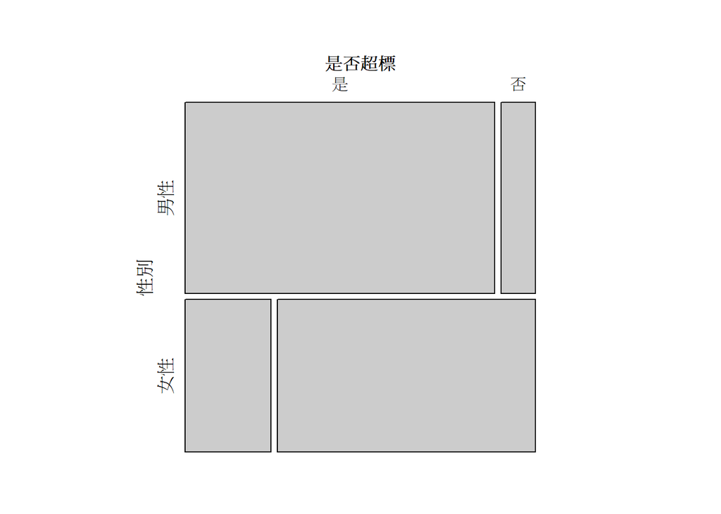

```r
dimnames(B) <- list("性別" = c("男性", "女性"), "是否超標" = c("是", "否"))
mosaic(B, main = "")
```

```r
ct <- chisq.test(B); ct
```

```
##
##  Pearson's Chi-squared test with Yates' continuity correction
##
## data:  B
## X-squared = 76.302, df = 1, p-value < 2.2e-16
```

```r
ct$residuals
```

```
##       是否超標
## 性別        是        否
##   男性  3.695479 -4.632528
##   女性 -4.131671  5.179324
```

- **結論：**
  - 根據卡方檢定，性別與超過安全標準的酒精攝取之間存在顯著關聯。
  - 根據標準化殘差分析，男性且超標的組別比期望次數多，而女性且超標的組別比期望次數少，因此與獨立（無關聯）的假設相比，本資料顯示男性更可能超標飲酒，進一步證明性別對酒精攝取行為有統計上的影響。

# 📊 Summary

- 本研究顯示，男性的超標酒精攝取機率為 **0.9**，而女性的超標機率為 **0.25**，兩者之間存在顯著差異。各項統計檢定結果如下：

| **檢定方法** | **結果** |
| --- | --- |
| **差異檢定** | 95% 信賴區間不包含 0，拒絕虛無假設，表明男性的超標機率顯著高於女性。 |
| **相對風險** | 男性的超標風險是女性的 **3.6 倍**，說明性別對酒精攝取行為有重要影響。 |
| **勝算比** | 男性的超標與未超標比例是女性的 **27 倍**，進一步證實性別對超標酒精攝取的影響顯著。 |
| **獨立性檢定** | p 值極小，拒絕性別與超標酒精攝取無關的假設，證明兩者之間確實存在顯著關聯。 |

- 綜合以上分析，**性別確實對超過安全標準的酒精攝取行為產生顯著影響，男性比女性更可能超標**。這些發現對於公共衛生政策具有重要意義，未來可針對不同性別群體制定更有效的飲酒教育與預防措施，以降低酒精相關的健康風險。